# Tanguy JEANNEAU & Adrien HANS

# Mise en oeuvre de l'algorithme EM

## Calcul de la valeur de la densité de probabilité d'un mélange de gaussienne en un point

### Les paramétres de la fonction gm_pdf

- x : le point où l'on calcule la valeur de la densitè
- mu : le vecteur des moyennes des gaussiennes
- sigma : le vecteur des écart-types des gaussiennes
- p : le vecteur des probabilitès de la loi multinomiale associèe

```python
import numpy as np
from scipy.stats import norm
from scipy.stats import uniform
import matplotlib.pyplot as plt
```

```python
def gm_pdf(x, mu, sigma, p):
    #Initialisation de la variable de sortie
    resultat = 0.0
    #Contrôle de la cohérence des paramètres d'entrée
    #Le vecteur de moyenne doit avoir la même longueur que le vecteur p
    if len(mu) != len(p):
        print('Erreur de dimension sur la moyenne')
    # Le vecteur des écart-types doit avoir la même longueur que le vecteur p
    elif len(sigma) != len(p):
            print('Erreur de dimension sur les écarts-types')
    else:
    # Calcul de la valeur de la densité
        for i in range(0, len(p)):
            resultat = resultat + p[i] * norm.pdf(x, mu[i], sigma[i])
    return resultat
```

## Génération de nombre aléatoire suivant un mélange de gaussienne

Dans un mélange de gaussienne chaque densité de probabilité correspondant à une loi normale est pondérée par un coefficient plus petit que un. La somme de tous ces coefficients est égale à un. Une variable aléatoire qui suit une loi normale suit donc une des lois normales du mélange avec une probabilité égale au coefficient de pondération de cette même loi normale. Pour générer un échantillon suivant une loi normale, il faut donc procéder en deux étapes :

1. Tirer aléatoirement un nombre entre 1 et N (le nombre de gaussiennes du mélange) suivant une loi mumltinomiale définie par les coefficients du mélange.
2. Une fois ce nombre obtenu, on génère le nombre suivant la loi normale associée.

### Les paramètres de la fonction gm_rnd

- mu : le vecteur des moyennes des gaussiennes
- sigma : le vecteur des écart-types des gaussiennes
- p : le vecteur des probabilités de la loi multinomiale associée

```python
def gm_rnd(mu, sigma, p):
    # Initialisation de la variable de sortie
    resultat = 0.0
    #Contrôle de la cohérence des paramètres d'entrée
    #Le vecteur de moyenne doit avoir la même longueur que le vecteur p
    if len(mu) != len(p):
        print('Erreur de dimension sur la moyenne')
    # Le vecteur des écart-types doit avoir la même longueur que le vecteur p
    elif len(sigma) != len(p):
            print('Erreur de dimension sur sur les écarts-types')
    else:
    #Génération de l'échantillon
    # On échantillonne suivant une loi uniforme sur [0,1]
        u = uniform.rvs(loc = 0.0, scale = 1.0, size = 1)
    # % Chaque test suivant permet de définir un intervalle sur lequel la
    # probabilité d'appartenance de la variable uniforme est égale à l'une des
    # probabilités définie dans le vecteur p. Lorsque u appartient à l'un de
    # ces intervalles, c'est équivalent à avoir générer une variable aléatoire
    # suivant l'un des éléments de p. Par exemple, pour le premier test
    # ci-dessous, la probabilité que u appartienne à l'intervalle [0,p[0][ est
    # égale à p[0] puisque u suit une loi uniforme. Donc si u appartient à
    # [0,p[0][ cela est équivalent à avoir tirer suivant l'événement de probabilité p[0].
        if u < p[0]: # On test si on a généré un événement de probabilité p[0]
            resultat = sigma[0] * norm.rvs(loc = 0, scale = 1, size = 1) + mu[0]
            # Pour générer suivant une loi normale quelconque, il suffit de multiplier
            # une variable normale centrée réduite (moyenne nulle et écart-type égal à 1)
            # par l'écart-type désité et d'additionner la moyenne désirée au produit précédent.
        for i in range(1, len(p)):
            if (u > np.sum(p[0:i])) and (u <= np.sum(p[0:i+1])): # On test si on a généré
                # un événement de probabilité p[i]
                resultat = sigma[i] * norm.rvs(loc = 0.0, scale = 1.0, size = 1) + mu[i]
                # Pour générer suivant une loi normale quelconque, il suffit de multiplier
                # une variable normale centrée réduite (moyenne nulle et écart-type égal à 1)
                # par l'écart-type désité et d'additionner la moyenne désirée au produit précédent.
    return resultat
```

## Traitement avec les données galaxy :

```python
from pandas import read_excel
```

```python
df = read_excel('Galaxy.xlsx', header=None)
```

```python
#données sous forme de liste :
donnees_galaxy=list(df[0])
#Taille des données galaxy :
M = len(donnees_galaxy)
```

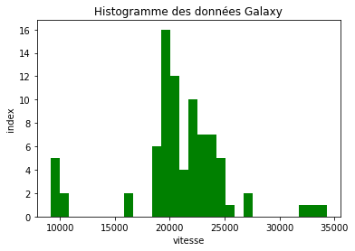

```
min: 9172
max: 34279
```

```python
plt.hist(donnees_galaxy, bins=30,density=False,color='green')
plt.title('Histogramme des données Galaxy')
plt.ylabel('index')
plt.xlabel('vitesse')
plt.show()

print('min: {}'.format(min(donnees_galaxy)))
print('max: {}'.format(max(donnees_galaxy)))
```

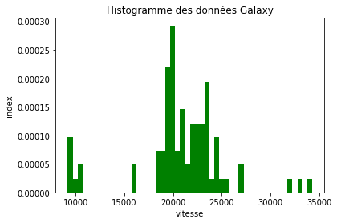

```python
plt.hist(donnees_galaxy, bins=50,density=True,color='green')
plt.title('Histogramme des données Galaxy')
plt.ylabel('index')
plt.xlabel('vitesse')
plt.show()
```

### Les paramètres de la densité de mélange de gaussienne

On essaie dans un premier temps de mélanger 5 gaussiennes :

```python
#Valeurs initiales
mu = np.array([10000, 20000, 22000, 24000, 33000])
sigma = np.array([300, 500, 500, 500, 300])
p = np.array([0.050, 0.4, 0.3,0.2, 0.05])
```

### Calcul de la densité de probabilité du mélange de gaussienne

```python
x = np.arange(9000, 35000, 1)
pointPdf = gm_pdf(x, mu, sigma, p)
```

### Tracé de la densité de probabilité du mélange de gaussienne et des données Galaxy :

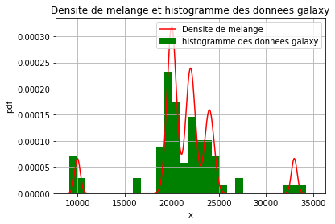

```python
plt.subplots
plt.plot(x, pointPdf, 'r-',label='Densite de melange')
plt.hist(donnees_galaxy, bins=30,density=True,color='green',label='histogramme des donnees galaxy')
plt.title('Densite de melange et histogramme des donnees galaxy')
plt.xlabel('x')
plt.ylabel('pdf')
plt.legend()
plt.grid()
plt.show()
```

La visualisation ci-dessus permet d'ajuster les paramètres $\mu,\sigma,\alpha$ pour chaque gaussienne en fonction de l'histogramme des données galaxy que l'ont essaie d'approcher.

### L'algorithme EM

Pour pouvoir utiliser les donnees galaxy, on execute cette ligne de code :

```python
donnees=donnees_galaxy
```

Pour avoir de bonnes valeurs de départ, on prend pour les valeurs $\mu$_em,$\sigma$_em et $\alpha$_em les valeurs que l'on a trouvé plus haut via les visualisations du mélange de gaussienne.

```python
#Nombre maximum d'itérations
nbMaxIterations = 70
#Valeurs initiales
mu_em = np.array([10000, 20000, 22000, 24000, 33000])
sigma_em = np.array([300, 500, 500, 500, 300])
alpha_em = np.array([0.050, 0.40, 0.300,0.2, 0.05])

nbIteration = 1 #Initialisation de la variable d'arrêt
nbComposante = len(alpha_em) #Nombre de composantes du mélange
nbDonnees = len(donnees)  #Nombre de données
p = np.zeros(shape=(nbComposante, nbDonnees))
#Déclaration et initialisation de la matrice qui va contenir les probabilités
#p(k|x,theta_courant)

#On ajoute la ligne suivante pour initialiser le nombre d'échantillons :
nbEchantillon = 1000
alpha_em_new = alpha_em
sigma_em_carre_new = sigma_em
mu_em_new = mu_em
donneesP = np.zeros(shape=(nbEchantillon))

while nbIteration < nbMaxIterations:
    for n in range(0, nbDonnees, 1):
        for k in range(0, nbComposante, 1):
            p[k, n] = alpha_em[k] * norm.pdf(x = donnees[n], loc = mu_em[k], scale = sigma_em[k])
        p[:, n] = p[:, n] / np.sum(p[:, n])
    for k in range(0, nbComposante, 1):
        alpha_em_new[k] = np.sum(p[k,:]) / nbDonnees
        for n in range(0, nbDonnees, 1):
            donneesP[n] = donnees[n] * p[k, n]
        mu_em_new[k]  = np.sum(donneesP) / np.sum(p[k, :])
        for n in range(nbDonnees):
            donneesP[n] = ((donnees[n] - mu_em_new[k]) ** 2) * p[k, n]
        sigma_em_carre_new[k] = np.sum(donneesP) / np.sum(p[k, :])
    mu_em = mu_em_new
    sigma_em = np.sqrt(sigma_em_carre_new)
    alpha_em = alpha_em_new
    nbIteration = nbIteration + 1
```

```python
print('Les paramètres estimés sont : ')
print('Moyennes des composantes du mélange', mu_em)
print('Ecrat type des composantes du mélange', sigma_em)
print('Probabilités des composantes du mélange', alpha_em)
```

```
Les paramètres estimés sont :
Moyennes des composantes du mélange [ 9710 20082 23179 24906 33044]
Ecrat type des composantes du mélange [ 422.5103549  1386.57671984  830.02409604 1593.28905099  921.7163338 ]
Probabilités des composantes du mélange [0.08536585 0.55372013 0.23424267 0.0900874  0.03658394]
```

```python
print('La somme des probabilités des composantes du mélange vaut : ', np.sum(alpha_em))
```

```
La somme des probabilités des composantes du mélange vaut :  1.0
```

La somme est 1 donc il n'y a pas de problème.

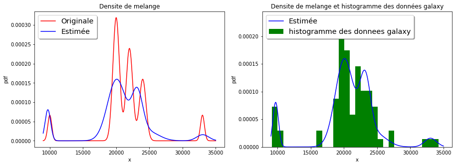

```python
plt.figure(figsize=(15,5))

plt.subplot(121)
plt.plot(x, pointPdf, 'r-', label = 'Originale')
plt.title('Densite de melange')
plt.xlabel('x')
plt.ylabel('pdf')
pointPdfEstime = gm_pdf(x, mu_em, sigma_em, alpha_em)
plt.plot(x, pointPdfEstime, 'b-', label = 'Estimée')
plt.legend(loc='upper left', shadow=True, fontsize='x-large')

plt.subplot(122)
plt.title('Densite de melange et histogramme des données galaxy')
plt.hist(donnees_galaxy, bins=30,density=True,color='green',label='histogramme des donnees galaxy')
plt.xlabel('x')
plt.ylabel('pdf')
pointPdfEstime = gm_pdf(x, mu_em, sigma_em, alpha_em)
plt.plot(x, pointPdfEstime, 'b-', label = 'Estimée')
plt.legend(loc='upper left', shadow=True, fontsize='x-large')


plt.show()
```

**On voit bien sur ces représentations que l'algorithme EM a permis d'affiner les paramètres initiaux pour se rapprocher des données galaxy.**

Par exemple, nous avons maintenant l'impression qu'il y a 4 gaussiennes alors que l'on en avait bien définies 5.

Même si ces résultats se rapprochent assez bien de la distributions des données magré seulement 5 gaussiennes, nous allons maintenant essayé d'avoir des résultats plus justes en testant sur plusieurs nombres de gaussiennes considérées :

## Essai avec plusieurs nombres de gaussiennes :

On défini ci-dessous une fonction algorithme_EM pour permettre de tester plusieurs paramètres sans avoir à réécrire le même code à chaque fois :

```python
def algorithme_EM(mu_em, sigma_em, alpha_em, nbMaxIterations,donnees):

    nbIteration = 1 #Initialisation de la variable d'arrêt
    nbComposante = len(alpha_em) #Nombre de composantes du mélange
    nbDonnees = len(donnees)  #Nombre de données
    p = np.zeros(shape=(nbComposante, nbDonnees))
    #Déclaration et initialisation de la matrice qui va contenir les probabilités
    #p(k|x,theta_courant)

    #On ajoute la ligne suivante pour initialiser le nombre d'échantillons :
    nbEchantillon = 100
    alpha_em_new = alpha_em
    sigma_em_carre_new = sigma_em
    mu_em_new = mu_em
    donneesP = np.zeros(shape=(nbEchantillon))

    while nbIteration < nbMaxIterations:
        for n in range(0, nbDonnees, 1):
            for k in range(0, nbComposante, 1):
                p[k, n] = alpha_em[k] * norm.pdf(x = donnees[n], loc = mu_em[k], scale = sigma_em[k])
            p[:, n] = p[:, n] / np.sum(p[:, n])
        for k in range(0, nbComposante, 1):
            alpha_em_new[k] = np.sum(p[k,:]) / nbDonnees

            for n in range(0, nbDonnees, 1):
                donneesP[n] = donnees[n] * p[k, n]
            mu_em_new[k]  = np.sum(donneesP) / np.sum(p[k, :])

            for n in range(nbDonnees):
                donneesP[n] = ((donnees[n] - mu_em_new[k]) ** 2) * p[k, n]
            sigma_em_carre_new[k] = np.nansum(donneesP) / (np.nansum(p[k, :])+1e-15)

        mu_em = mu_em_new
        sigma_em = np.sqrt(sigma_em_carre_new)
        alpha_em = alpha_em_new
        nbIteration = nbIteration + 1

    return mu_em, sigma_em, alpha_em
```

On va maintenant faire une boucle for sur un nombre de gaussiennes et afficher le résultat pour chaque itération :

```python
nbGaussiennesMax=15
nbMaxIterations=80
```

```
pour 6 gaussiennes
Les paramètres estimés sont :
Moyennes des composantes du mélange [ 9710.14285712 16126.99922138 23537.60834587 33044.42875357
 19801.04562967 22760.86355474]
Ecrat type des composantes du mélange [ 422.5103549    42.98837052 1938.22470318  921.71579134  677.19568811
  940.71143291]
Probabilités des composantes du mélange [0.08536585 0.02438507 0.20368688 0.03658149 0.40135842 0.24862229]
```

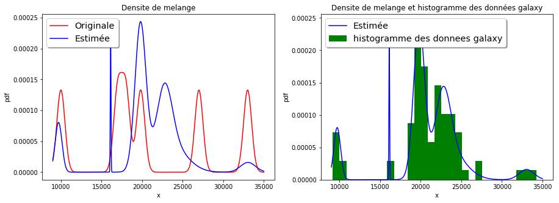

```
pour 7 gaussiennes
Les paramètres estimés sont :
Moyennes des composantes du mélange [ 9710.14285714 16126.99999621 26977.5013992  33044.33333326
 18522.58431612 19860.84764244 22850.89151195]
Ecrat type des composantes du mélange [ 422.5103549    42.98837052   17.49285568  921.71741874   76.24959016
  553.19164853 1244.38940851]
Probabilités des composantes du mélange [0.08536585 0.02439023 0.02434848 0.03658537 0.03200989 0.35735878
 0.43994141]
```

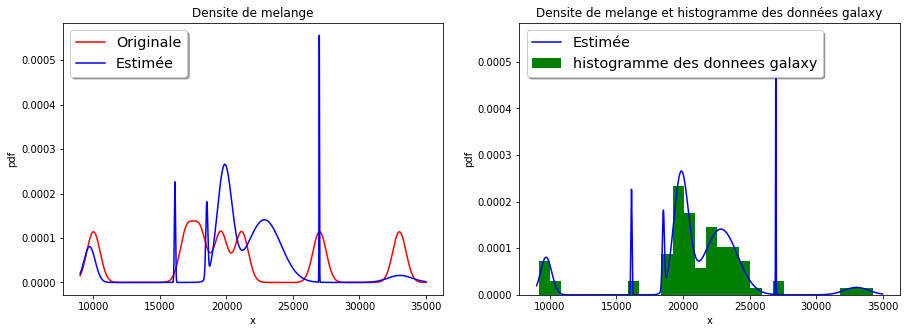

```
pour 8 gaussiennes
Les paramètres estimés sont :
Moyennes des composantes du mélange [ 9710.14285714 16126.99999919 26977.50116083 33044.33333326
 18522.42986486 19652.81498503 20476.2831112  22928.3705292 ]
Ecrat type des composantes du mélange [ 422.5103549    42.98837052   17.49285568  921.71741874   76.57675888
  416.44687536  446.16140577 1193.39138593]
Probabilités des composantes du mélange [0.08536585 0.02439024 0.02435774 0.03658537 0.03447618 0.25627511
 0.11419465 0.42435486]
```

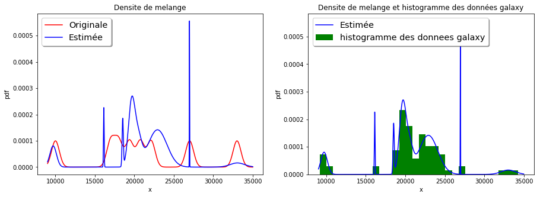

```
pour 9 gaussiennes
Les paramètres estimés sont :
Moyennes des composantes du mélange [ 9710.14285714 16127.         26977.50058866 33044.33333326
 18522.41467075 19624.37400084 20468.9968979  22134.4933883
 23440.90511764]
Ecrat type des composantes du mélange [422.5103549   42.98837052  17.49285568 921.71741874  76.58328799
 408.85205148 572.99650959 241.74780247 978.00766868]
Probabilités des composantes du mélange [0.08536585 0.02439024 0.02437755 0.03658537 0.03451353 0.22475236
 0.18734895 0.08585445 0.29681169]
```

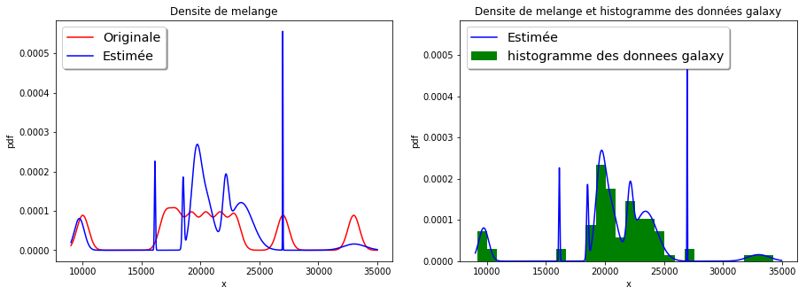

```
pour 10 gaussiennes
Les paramètres estimés sont :
Moyennes des composantes du mélange [ 9710.14285714 16127.         26977.50062534 33044.33333326
 18523.16850281 19394.7243517  20072.87038032 20862.87005519
 22089.39956515 23434.3892642 ]
Ecrat type des composantes du mélange [422.5103549   42.98837052  17.49285568 921.71741874  76.6093989
 262.39092972 182.00824157 144.05207392 302.5855251  986.12423152]
Probabilités des composantes du mélange [0.08536585 0.02439024 0.02437657 0.03658537 0.03619849 0.15714228
 0.16015911 0.08106767 0.09787521 0.2968392 ]
```

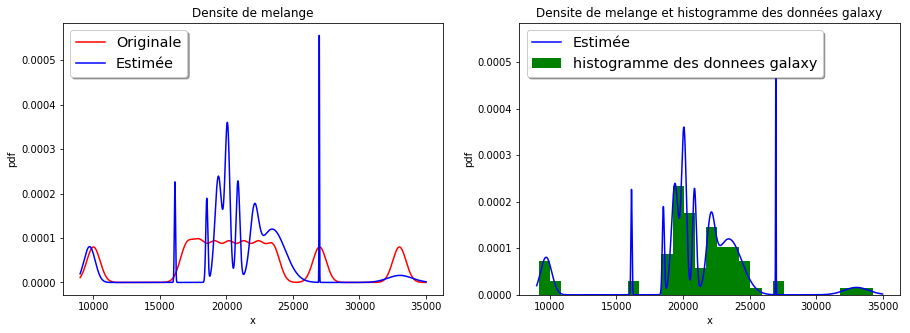

```
pour 11 gaussiennes
Les paramètres estimés sont :
Moyennes des composantes du mélange [ 9710.14285714 16127.         26977.50035027 33044.33333326
 18523.15563452 19396.34047067 20073.9317322  20865.27153897
 22171.97418787 23349.73416743 24217.75908039]
Ecrat type des composantes du mélange [422.5103549   42.98837052  17.49285568 921.71741874  76.6093989
 263.71196408 182.01098868 146.73104648 387.91880594 345.29262952
 751.88163962]
Probabilités des composantes du mélange [0.08536585 0.02439024 0.02438451 0.03658537 0.03618578 0.15772003
 0.15999116 0.0835951  0.16918786 0.09778091 0.12481319]
```

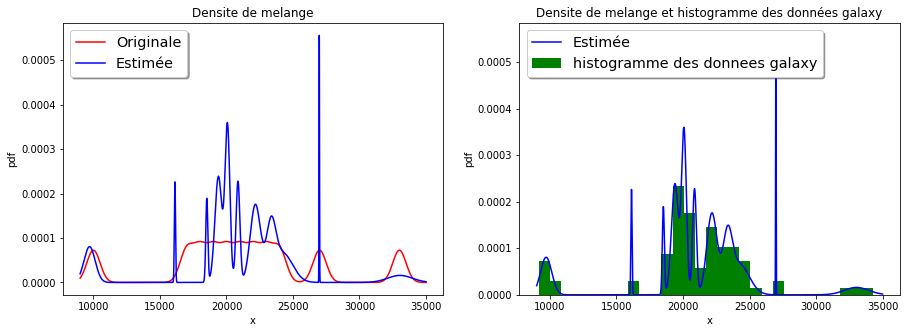

```
pour 12 gaussiennes
Les paramètres estimés sont :
Moyennes des composantes du mélange [ 9710.14285714 16127.         26977.50019585 33044.33333326
 18523.15634969 19396.25325462 20073.87741027 20865.6606123
 22031.21779181 22615.24057505 23558.33532523 24373.44353816]
Ecrat type des composantes du mélange [422.5103549   42.98837052  17.49285568 921.71741874  76.6093989
 263.63990593 182.01098868 146.98639393 312.25950746 547.46780727
 145.28592499 676.24182065]
Probabilités des composantes du mélange [0.08536585 0.02439024 0.0243875  0.03658537 0.03618649 0.15768981
 0.16001093 0.08364894 0.08082661 0.14525978 0.05787268 0.10777579]
```

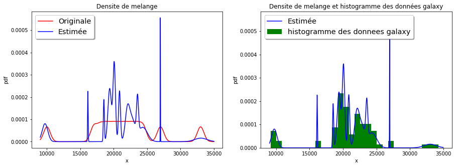

```
pour 13 gaussiennes
Les paramètres estimés sont :
Moyennes des composantes du mélange [ 9710.14285714 16127.         26977.50029204 33044.33333326
 18523.16198592 19395.49707322 20072.29456173 20862.00242455
 21618.15939771 22148.86860447 23253.41957982 23865.19130367
 24813.03260788]
Ecrat type des composantes du mélange [422.5103549   42.98837052  17.49285568 921.71741874  76.6093989
 263.03041649 180.94474295 141.55564277 773.77645351 338.93657224
 404.74559911 560.52743019 611.73932357]
Probabilités des composantes du mélange [0.08536585 0.02439024 0.02438621 0.03658537 0.03619116 0.15733031
 0.15866173 0.07866106 0.02263279 0.14202405 0.10028353 0.08897908
 0.04450863]
```

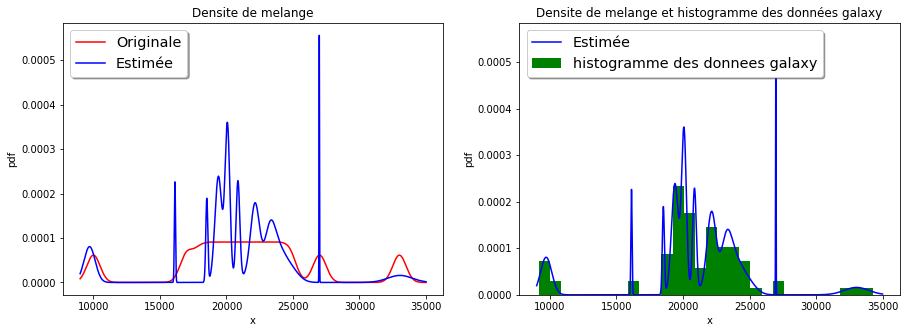

```
pour 14 gaussiennes
Les paramètres estimés sont :
Moyennes des composantes du mélange [ 9710.14285714 16127.         26977.50001482 33044.33333326
 18523.1783878  19377.99891566 20081.10123025 19949.61590805
 20868.13121848 22128.51213822 23066.01072188 23614.63637742
 24266.80694959 25058.14411446]
Ecrat type des composantes du mélange [422.5103549   42.98837052  17.49285568 921.71741874  76.6093989
 257.39269609 175.37103524 280.25167261 146.93876276 349.2076746
 265.59367462  88.3402513   85.51023331 427.74291344]
Probabilités des composantes du mélange [0.08536585 0.02439024 0.02439013 0.03658537 0.03621184 0.14687591
 0.12921314 0.04211994 0.08366049 0.15818812 0.08167609 0.06590985
 0.04629037 0.03912266]
```

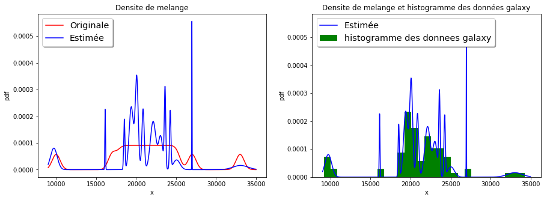

```python
for i in range(6,nbGaussiennesMax):

    mu_em = np.array([10000, 17000,27000,33000] + [18000 + 11000*((k)/i) for k in range(0,i-4)])
    sigma_em = np.array([500]*i)
    alpha_em = np.array([1/i]*i)

    pointPdf = gm_pdf(x, mu_em, sigma_em, alpha_em)
    mu_em, sigma_em, alpha_em = algorithme_EM(mu_em,sigma_em,alpha_em,nbMaxIterations,donnees_galaxy)
    pointPdfEstime = gm_pdf(x, mu_em, sigma_em, alpha_em)

    print('pour %i gaussiennes ' %i)
    print('Les paramètres estimés sont : ')
    print('Moyennes des composantes du mélange', mu_em)
    print('Ecrat type des composantes du mélange', sigma_em)
    print('Probabilités des composantes du mélange', alpha_em)

    plt.figure(figsize=(15,5))

    plt.subplot(1,2,1)
    plt.plot(x, pointPdf, 'r-', label = 'Originale')
    plt.title('Densite de melange')
    plt.xlabel('x')
    plt.ylabel('pdf')
    plt.plot(x, pointPdfEstime, 'b-', label = 'Estimée')
    plt.legend(loc='upper left', shadow=True, fontsize='x-large')

    plt.subplot(1,2,2)
    plt.title('Densite de melange et histogramme des données galaxy')
    plt.hist(donnees_galaxy, bins=30,density=True,color='green',label='histogramme des donnees galaxy')
    plt.xlabel('x')
    plt.ylabel('pdf')
    pointPdfEstime = gm_pdf(x, mu_em, sigma_em, alpha_em)
    plt.plot(x, pointPdfEstime, 'b-', label = 'Estimée')
    plt.legend(loc='upper left', shadow=True, fontsize='x-large')


    plt.show()
```

# Conclusion :

Nous avions une erreur sur `np.sum(donneesP)` par exemple, car il y avait des nans, donc nous avons utilisé np.nansum au lieu de np.sum et nous avons empécher la possibilité de division par 0.

**Nous observons via ces représentations graphiques que :**

- De manière générale, et comme attendu, plus le nombre de gaussiennes est important, plus la courbe estimée se rapproche de la distribution des données galaxy.
- Cependant, on observe tout de même une très grande sensibilité à peu d'évènements. (pic vers 27000 apparaissant entre 6 et 7 gaussiennes par exemple). Ceci est sûrement dû au fait que l'on attribue la même valeur de probabilité pour toutes les gaussiennes peu importe leurs positions initialement, et que le centre (la moyenne) d'une gaussienne se trouve à l'endroit de ce groupe de données. Nous observons d'ailleurs que sur le nombre de gaussiennes considéré, les meilleurs résultats sont finalement ceux obtenus pour 13 gaussiennes-en tout cas visuellement- à cause de l'apparition de deux pics juste avant 25000 qui ont une 'intensité' bien plus importante que la distribution des données à cet endroit. Par contre, cette même constatation est sûrement dû aussi au peu de gaussiennes considérées. On peut en effet s'attendre à avoir des résultats très très proche étant donné le comportement de l'algorithme, pour un très grand nombre de gaussiennes (ces mêmes pics 'étonnants' ne seraient alors pas d'une intensité aussi importante)
- On a vu aussi que l'algorithme peut être instable en fonction du nombre de gaussienne considéré et des conditions initiales(il ne retourne que des nans dans certains cas) et qu'il dépend très fortement de ces conditions initiales.

Il serait alors peut-être judicieux de tester plusieurs formes de conditions initiales (ou d'avoir un algorithme permettant de déterminer les meilleures en en testant plusieurs directement) afin d'avoir des résultats plus proches des données considérées.